# Benchmarking linear N-dimensional interpolators

*Rationale*

A fast and simple interpolation routine is needed in the Stochastic Dynamic Programming algorithm. The "fast and simple" requirement leads to choose the *linear interpolation* method.

The method needs to be applicable to N-dimensional input, i.e. to interpolate a scalar function :

$x\mapsto f(x)\in\mathbb{R} ,\quad x\in D \subset \mathbb{R}^n$

where the dimension $n$ will be *in practice* less than 3 or 4.

We here try to evaluate what routines can be found "off-the-shelf".

*References*

- `scipy.interpolate` doc http://docs.scipy.org/doc/scipy/reference/interpolate.html
- `scipy.ndimage` doc
- interpolation in the `dolo` project: https://github.com/EconForge/dolo/tree/master/dolo/numeric/interpolation (Multilinear interpolation removed since then...)

Update February 2015: add [scipy.interpolate.RegularGridInterpolator](http://docs.scipy.org/doc/scipy-dev/reference/generated/scipy.interpolate.RegularGridInterpolator.html) in the benchmark (added in `scipy` 0.14, released in May 2014)

```python
import numpy as np
from numpy import pi
import matplotlib.pyplot as plt
import matplotlib as mpl
%matplotlib inline
```

```python
from scipy.interpolate import (
    LinearNDInterpolator, RectBivariateSpline,
    RegularGridInterpolator)
from scipy.ndimage import map_coordinates
from dolointerpolation import MultilinearInterpolator
```

```python
# Tweak how images are plotted with imshow
mpl.rcParams['image.interpolation'] = 'none' # no interpolation
mpl.rcParams['image.origin'] = 'lower' # origin at lower left corner
mpl.rcParams['image.cmap'] = 'RdBu_r'
```

## 1) Define a simple interpolation problem

```python
def f_2d(x,y):
    '''a function with 2D input to interpolate on [0,1]'''
    twopi = 2*pi
    return np.exp(-x)*np.cos(x*2*pi)*np.sin(y*2*pi)

# quick check :
f_2d(0,0.25)
```

```
1.0
```

```python
def f_3d(x,y,z):
    '''a function with 3D input to interpolate on [0,1]'''
    twopi = 2*pi
    return np.sin(x*2*pi)*np.sin(y*2*pi)*np.sin(z*2*pi)

# quick check :
f_3d(0.25,0.25,0.25)
```

```
1.0
```

#### Build the 2D and 3D data grids

```
(50, 51)
```

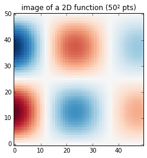

```python
Ndata = 50
xgrid = np.linspace(0,1, Ndata)
ygrid = np.linspace(0,1, Ndata+1) # use a slighly different size to check differences
zgrid = np.linspace(0,1, Ndata+2)

f_2d_grid = f_2d(xgrid.reshape(-1,1), ygrid)

plt.imshow(f_2d_grid.T)
plt.title(u'image of a 2D function ({}² pts)'.format(Ndata));

f_2d_grid.shape
```

The 3D case

```python
f_3d_grid = f_3d(xgrid.reshape(-1,1,1), ygrid.reshape(1,-1,1), zgrid)
f_3d_grid.shape
```

```
(50, 51, 52)
```

## 2) Use interpolators

Try several interpolation routines.

Notice how each routine has its special way (API) to

1. build the interpolator (instanciation)
2. call the interpolator (evaluation)

```python
# Define the grid to interpolate on :
Ninterp = 1000
xinterp = np.linspace(0,1, Ninterp)
yinterp = np.linspace(0,1, Ninterp+1) # use a slighly different size to check differences
zinterp = np.linspace(0,1, 5) # small dimension to avoid size explosion
```

### a) LinearNDInterpolator

`LinearNDInterpolator` uses an *unstructured data* which is provided as a list of points. There is also a cousin : `NearestNDInterpolator`

`LinearNDInterpolator(points, values)` ([documentation](http://docs.scipy.org/doc/scipy/reference/generated/scipy.interpolate.LinearNDInterpolator.html))

**Performance** :

- instanciation :
- 18 ms for 50x50 pts,
- but **19.1 s** for 50x50x50 pts
- evaluation : 45 ms for 1 Mpts.

```python
# Build data for the interpolator
points_x, points_y = np.broadcast_arrays(xgrid.reshape(-1,1), ygrid)
points = np.vstack((points_x.flatten(),
                    points_y.flatten())).T
values = f_2d_grid.flatten()
```

```python
# Build
%timeit f_2d_interp = LinearNDInterpolator(points, values)
```

```
100 loops, best of 3: 17.7 ms per loop
```

```python
f_2d_interp = LinearNDInterpolator(points, values)
```

```python
# Evaluate
%timeit f_2d_interp(xinterp.reshape(-1,1), yinterp)
```

```
10 loops, best of 3: 44.7 ms per loop
```

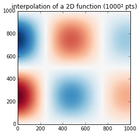

```python
# Display
plt.imshow(f_2d_interp(xinterp.reshape(-1,1), yinterp).T)
plt.title(u'interpolation of a 2D function ({}² pts)'.format(Ninterp));
```

The 3D case : **terrible performance !**

```python
# Build data for the interpolator
points_x, points_y, points_z = np.broadcast_arrays(xgrid.reshape(-1,1,1), ygrid.reshape(1,-1,1), zgrid)
points = np.vstack((points_x.flatten(),
                    points_y.flatten(),
                    points_z.flatten()
                  )).T
values = f_3d_grid.flatten()
points.shape
```

```
(132600, 3)
```

```python
%time f_3d_interp = LinearNDInterpolator(points, values)
```

```
CPU times: user 19.1 s, sys: 88 ms, total: 19.2 s
Wall time: 19.2 s
```

```python
f_3d_interp = LinearNDInterpolator(points, values)
```

```python
# Evaluate:
%time f_3d_interp(xinterp.reshape(-1,1), np.linspace(0,1,5), 0.25);
```

```
CPU times: user 2min 44s, sys: 0 ns, total: 2min 44s
Wall time: 2min 44s
```

```
array([[  0.00000000e+00,   0.00000000e+00,   0.00000000e+00,
          0.00000000e+00,   0.00000000e+00],
       [  0.00000000e+00,   6.23317279e-03,   7.64852773e-19,
         -6.23317279e-03,  -1.53553034e-18],
       [  0.00000000e+00,   1.24663456e-02,   1.52970555e-18,
         -1.24663456e-02,  -3.07106068e-18],
       ...,
       [  0.00000000e+00,  -1.25138148e-02,  -1.53553034e-18,
          1.25138148e-02,   3.07106068e-18],
       [  0.00000000e+00,  -6.25690738e-03,  -7.67765169e-19,
          6.25690738e-03,   1.53553034e-18],
       [  0.00000000e+00,  -2.44098405e-16,  -2.99525375e-32,
          2.44098405e-16,   5.99050750e-32]])
```

Interpolation on a slice along the x-axis, just to check that it works.

```python
f_3d_interp_grid = f_3d_interp(xinterp.reshape(-1,1,1), 0.25, 0.25)
```

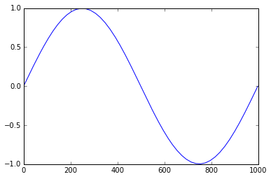

```python
plt.plot(f_3d_interp_grid.flatten());
```

### b) RectBivariateSpline (scipy.interpolate)

*for 2D interpolation only !*

`RectBivariateSpline(x, y, z, bbox=[None, None, None, None], kx=3, ky=3, s=0)` ([documentation](http://docs.scipy.org/doc/scipy/reference/generated/scipy.interpolate.RectBivariateSpline.html))

- x,y : 1-D arrays of coordinates in strictly ascending order.
- z : 2-D array of data with shape (x.size,y.size).

**Performance**

- instanciation : 0.2 ms for 50x50 pts
- evaluation : 21 ms for 1 Mpts

```python
%%timeit # Build
f_2d_interp = RectBivariateSpline(xgrid, ygrid, f_2d_grid)
```

```
10000 loops, best of 3: 192 µs per loop
```

```python
f_2d_interp = RectBivariateSpline(xgrid, ygrid, f_2d_grid)
```

```python
%%timeit # Evaluate
f_2d_interp(xinterp, yinterp)
```

```
10 loops, best of 3: 21.2 ms per loop
```

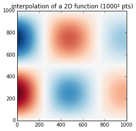

```python
# Display
plt.imshow(f_2d_interp(xinterp, yinterp).T)
plt.title(u'interpolation of a 2D function ({}² pts)'.format(Ninterp));
```

### c) map_coordinates (scipy.ndimage)

notice that this method has no separation between *instanciation* and *evaluation* !

`map_coordinates(input, coordinates, output=None, order=3, mode='constant', cval=0.0, prefilter=True)` ([documentation](http://docs.scipy.org/doc/scipy/reference/generated/scipy.ndimage.interpolation.map_coordinates.html))

**Performance** :

- 56 ms (instanciation + evaluation 1Mpts)
- 511 ms (5 Mpts in 3D)

```python
# Prepare the coordinates to evaluate the array on :
points_x, points_y = np.broadcast_arrays(xinterp.reshape(-1,1), yinterp)
coord = np.vstack((points_x.flatten()*(len(xgrid)-1) , # a weird formula !
                   points_y.flatten()*(len(ygrid)-1)))
coord.shape
```

```
(2, 1001000)
```

```python
%%timeit # Build and Evaluate
f_2d_interp = map_coordinates(f_2d_grid, coord, order=1)
# Reshape
f_2d_interp = f_2d_interp.reshape(len(xinterp), len(yinterp))
```

```
10 loops, best of 3: 56.4 ms per loop
```

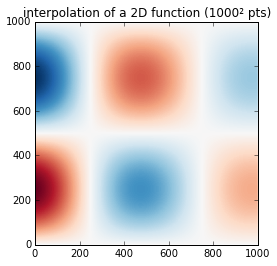

```python
# Display
f_2d_interp = map_coordinates(f_2d_grid, coord, order=1).reshape(len(xinterp), len(yinterp))

plt.imshow(f_2d_interp.T)
plt.title(u'interpolation of a 2D function ({}² pts)'.format(Ninterp));
```

The 3D case

```python
# Prepare the coordinates to evaluate the array on :
points_x, points_y, points_z = np.broadcast_arrays(xinterp.reshape(-1,1,1), yinterp.reshape(1,-1,1), zinterp)
coord = np.vstack((points_x.flatten()*(len(xgrid)-1), # a weird formula !
                   points_y.flatten()*(len(ygrid)-1),
                   points_z.flatten()*(len(zgrid)-1)
                   ))
coord.shape
```

```
(3, 5005000)
```

```python
%%timeit # Build and Evaluate
f_3d_interp = map_coordinates(f_3d_grid, coord, order=1)
# Reshape
f_3d_interp = f_3d_interp.reshape(len(xinterp), len(yinterp), len(zinterp))
```

```
1 loops, best of 3: 511 ms per loop
```

```python
f_3d_interp = map_coordinates(f_3d_grid, coord, order=1)
f_3d_interp = f_3d_interp.reshape(len(xinterp), len(yinterp), len(zinterp))
f_3d_interp.shape
```

```
(1000, 1001, 5)
```

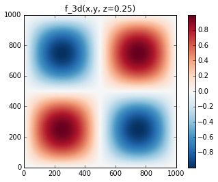

```python
n_z = 1
plt.imshow(f_3d_interp[:,:,n_z])
plt.title('f_3d(x,y, z={:.2f})'.format(zinterp[n_z]))
plt.colorbar();
```

### d) MultilinearInterpolator from Pablo Winant

**Performance** :

- 0.010 ms for instanciation. 13 ms for evaluation 1Mpts
- 105 ms (5 Mpts in 3D)

References :

- Pablo Winant homepage : http://www.mosphere.fr
- on GitHub https://github.com/albop/dolo/tree/master/dolo/numeric/interpolation
- documentation : http://albop.github.io/dolo/interpolation.html
- related thread on Scipy-dev http://mail.scipy.org/pipermail/scipy-dev/2013-February/018389.html http://mail.scipy.org/pipermail/scipy-dev/2013-May/018776.html

```python
smin = [xgrid[0], ygrid[0]]
smax = [xgrid[-1], ygrid[-1]]
orders = [len(xgrid), len(ygrid)]

print(smin, smax, orders)
```

```
([0.0, 0.0], [1.0, 1.0], [50, 51])
```

```python
%%timeit
minterp = MultilinearInterpolator(smin,smax,orders)
minterp.set_values(np.atleast_2d(f_2d_grid.flatten()))
```

```
100000 loops, best of 3: 9.47 µs per loop
```

```python
minterp.grid.shape
```

```
(2, 2550)
```

```python
f_2d_grid.shape
```

```
(50, 51)
```

```python
# Prepare the coordinates to evaluate the array on :
points_x, points_y = np.broadcast_arrays(xinterp.reshape(-1,1), yinterp)
coord = np.vstack((points_x.flatten(),
                   points_y.flatten()))
coord.shape
```

```
(2, 1001000)
```

```python
%timeit f_2d_interp = minterp(coord).reshape(len(xinterp), len(yinterp))
```

```
100 loops, best of 3: 12.6 ms per loop
```

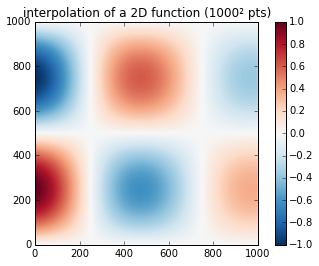

```python
# Display
f_2d_interp = minterp(coord).reshape(len(xinterp), len(yinterp))

plt.imshow(f_2d_interp.T)
plt.title(u'interpolation of a 2D function ({}² pts)'.format(Ninterp));
plt.colorbar();
```

#### The 3D case

```python
smin = [xgrid[0], ygrid[0], zgrid[0]]
smax = [xgrid[-1], ygrid[-1], zgrid[-1]]
orders = [len(xgrid), len(ygrid), len(zgrid)]

print(smin, smax, orders)
```

```
([0.0, 0.0, 0.0], [1.0, 1.0, 1.0], [50, 51, 52])
```

```python
minterp = MultilinearInterpolator(smin,smax,orders)
minterp.set_values(np.atleast_2d(f_3d_grid.flatten()))
```

```python
# Prepare the coordinates to evaluate the array on :
points_x, points_y, points_z = np.broadcast_arrays(xinterp.reshape(-1,1,1), yinterp.reshape(1,-1,1), zinterp)
coord = np.vstack((points_x.flatten(), # a weird formula !
                   points_y.flatten(),
                   points_z.flatten()
                   ))
coord.shape
```

```
(3, 5005000)
```

*A very nice interpolation performance !*

```python
%timeit minterp(coord)
```

```
10 loops, best of 3: 105 ms per loop
```

```python
f_3d_interp = minterp(coord)
f_3d_interp = f_3d_interp.reshape(len(xinterp), len(yinterp), len(zinterp))
f_3d_interp.shape
```

```
(1000, 1001, 5)
```

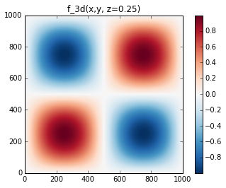

```python
n_z = 1
plt.imshow(f_3d_interp[:,:,n_z])
plt.title('f_3d(x,y, z={:.2f})'.format(zinterp[n_z]))
plt.colorbar();
```

Interpolation throuput:

```python
print('{:.1f} Mpts/s'.format(5e6 / 0.105 /1e6) )
```

```
47.6 Mpts/s
```

### e) RegularGridInterpolator (scipy.interpolate, starting v0.14)

[documentation](http://docs.scipy.org/doc/scipy-dev/reference/generated/scipy.interpolate.RegularGridInterpolator.html)

actual interpolation code: https://github.com/scipy/scipy/blob/master/scipy/interpolate/interpolate.py#L1577 (pure Python, no Cython involved!)

API:

`RegularGridInterpolator(points, values, [...])`

- `points`: tuple of ndarray of float, with shapes *(m1, ), ..., (mn, )*.  
  → The points defining the regular grid in n dimensions.
- `value`: array_like, shape *(m1, ..., mn, ...)*.  
  → The data on the regular grid in n dimensions.

**Performance**

```python
%%timeit # Instanciate the interpolator
f_2d_interp = RegularGridInterpolator((xgrid, ygrid), f_2d_grid)
```

```
10000 loops, best of 3: 21.6 µs per loop
```

```python
f_2d_interp = RegularGridInterpolator((xgrid, ygrid), f_2d_grid)
```

```python
# Prepare the coordinates to evaluate the array on :
points_x, points_y = np.broadcast_arrays(xinterp.reshape(-1,1), yinterp)
coord = np.vstack((points_x.flatten(),
                   points_y.flatten()))
coord.shape
```

```
(2, 1001000)
```

```python
f_2d_interp
```

```
<scipy.interpolate.interpolate.RegularGridInterpolator at 0x7fe0c4933ed0>
```

```python
%%timeit # Interpolate
f_2d_interp_res = f_2d_interp(coord.T).reshape(len(xinterp), len(yinterp))
```

```
10 loops, best of 3: 112 ms per loop
```

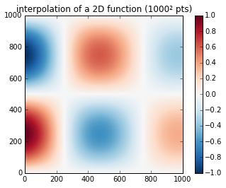

```python
# Display

f_2d_interp_res = f_2d_interp(coord.T).reshape(len(xinterp), len(yinterp))

plt.imshow(f_2d_interp_res.T)
plt.title(u'interpolation of a 2D function ({}² pts)'.format(Ninterp));
plt.colorbar();
```

#### The 3D case

```python
f_3d_interp = RegularGridInterpolator((xgrid, ygrid, zgrid), f_3d_grid)
```

```python
# Prepare the coordinates to evaluate the array on :
points_x, points_y, points_z = np.broadcast_arrays(xinterp.reshape(-1,1,1), yinterp.reshape(1,-1,1), zinterp)
coord = np.vstack((points_x.flatten(), # a weird formula !
                   points_y.flatten(),
                   points_z.flatten()
                   ))
coord.shape
```

```
(3, 5005000)
```

```python
%%timeit # Interpolate
f_3d_interp_res = f_3d_interp(coord.T).reshape(len(xinterp), len(yinterp), len(zinterp))
```

```
1 loops, best of 3: 1.8 s per loop
```

Conclusion: Dolo's Multilinear interpolation (for an *even grid* only) is still the best!